# Severe Weather Disaster and Its Impacts on Economy and Public Health

WendyD

9/2/2020

# Sypnosis

In this particular project, we are investigating the impact of storm and severe weather phenomenon on the US economy and public health. We used the data provided by the National Oceanic and Atmospheric Administration.

To carry out the analysis, we looked at the fatalities and injuries counts for public health impact estimation. On the other hand, we also analyzed property damage and crop damage, to better understand the economic consequences. From these analysis, we drew conclusions on which severe weather type cause the most impacts, public health and economic wise.

# Data Processing

First we download the data from NOAA database, and then use read.csv to read data

```r
download.file("https://d396qusza40orc.cloudfront.net/repdata%2Fdata%2FStormData.csv.bz2", destfile = "stormdata")
data1<-read.csv("./stormdata")
dim(data1)
```

```
## [1] 902297     37
```

We saw that the storm data has 902297 observation with total 37 different values/columns

# Data Analysis

We take a closer look at the data

```r
head(data1, n=5)
```

```
##   STATE__           BGN_DATE BGN_TIME TIME_ZONE COUNTY COUNTYNAME STATE  EVTYPE
## 1       1  4/18/1950 0:00:00     0130       CST     97     MOBILE    AL TORNADO
## 2       1  4/18/1950 0:00:00     0145       CST      3    BALDWIN    AL TORNADO
## 3       1  2/20/1951 0:00:00     1600       CST     57    FAYETTE    AL TORNADO
## 4       1   6/8/1951 0:00:00     0900       CST     89    MADISON    AL TORNADO
## 5       1 11/15/1951 0:00:00     1500       CST     43    CULLMAN    AL TORNADO
##   BGN_RANGE BGN_AZI BGN_LOCATI END_DATE END_TIME COUNTY_END COUNTYENDN
## 1         0                                               0         NA
## 2         0                                               0         NA
## 3         0                                               0         NA
## 4         0                                               0         NA
## 5         0                                               0         NA
##   END_RANGE END_AZI END_LOCATI LENGTH WIDTH F MAG FATALITIES INJURIES PROPDMG
## 1         0                      14.0   100 3   0          0       15    25.0
## 2         0                       2.0   150 2   0          0        0     2.5
## 3         0                       0.1   123 2   0          0        2    25.0
## 4         0                       0.0   100 2   0          0        2     2.5
## 5         0                       0.0   150 2   0          0        2     2.5
##   PROPDMGEXP CROPDMG CROPDMGEXP WFO STATEOFFIC ZONENAMES LATITUDE LONGITUDE
## 1          K       0                                         3040      8812
## 2          K       0                                         3042      8755
## 3          K       0                                         3340      8742
## 4          K       0                                         3458      8626
## 5          K       0                                         3412      8642
##   LATITUDE_E LONGITUDE_ REMARKS REFNUM
## 1       3051       8806              1
## 2          0          0              2
## 3          0          0              3
## 4          0          0              4
## 5          0          0              5
```

```r
summary(data1)
```

```
##     STATE__       BGN_DATE           BGN_TIME          TIME_ZONE
##  Min.   : 1.0   Length:902297      Length:902297      Length:902297
##  1st Qu.:19.0   Class :character   Class :character   Class :character
##  Median :30.0   Mode  :character   Mode  :character   Mode  :character
##  Mean   :31.2
##  3rd Qu.:45.0
##  Max.   :95.0
##
##      COUNTY       COUNTYNAME           STATE              EVTYPE
##  Min.   :  0.0   Length:902297      Length:902297      Length:902297
##  1st Qu.: 31.0   Class :character   Class :character   Class :character
##  Median : 75.0   Mode  :character   Mode  :character   Mode  :character
##  Mean   :100.6
##  3rd Qu.:131.0
##  Max.   :873.0
##
##    BGN_RANGE          BGN_AZI           BGN_LOCATI          END_DATE
##  Min.   :   0.000   Length:902297      Length:902297      Length:902297
##  1st Qu.:   0.000   Class :character   Class :character   Class :character
##  Median :   0.000   Mode  :character   Mode  :character   Mode  :character
##  Mean   :   1.484
##  3rd Qu.:   1.000
##  Max.   :3749.000
##
##    END_TIME           COUNTY_END COUNTYENDN       END_RANGE
##  Length:902297      Min.   :0    Mode:logical   Min.   :  0.0000
##  Class :character   1st Qu.:0    NA's:902297    1st Qu.:  0.0000
##  Mode  :character   Median :0                   Median :  0.0000
##                     Mean   :0                   Mean   :  0.9862
##                     3rd Qu.:0                   3rd Qu.:  0.0000
##                     Max.   :0                   Max.   :925.0000
##
##    END_AZI           END_LOCATI            LENGTH              WIDTH
##  Length:902297      Length:902297      Min.   :   0.0000   Min.   :   0.000
##  Class :character   Class :character   1st Qu.:   0.0000   1st Qu.:   0.000
##  Mode  :character   Mode  :character   Median :   0.0000   Median :   0.000
##                                        Mean   :   0.2301   Mean   :   7.503
##                                        3rd Qu.:   0.0000   3rd Qu.:   0.000
##                                        Max.   :2315.0000   Max.   :4400.000
##
```

[output cut: 25 more lines]

```
##  Min.   :-14451   Min.   :   0   Min.   :-14455   Length:902297
##  1st Qu.:  7247   1st Qu.:   0   1st Qu.:     0   Class :character
##  Median :  8707   Median :   0   Median :     0   Mode  :character
##  Mean   :  6940   Mean   :1452   Mean   :  3509
##  3rd Qu.:  9605   3rd Qu.:3549   3rd Qu.:  8735
##  Max.   : 17124   Max.   :9706   Max.   :106220
##                   NA's   :40
##      REFNUM
##  Min.   :     1
##  1st Qu.:225575
##  Median :451149
##  Mean   :451149
##  3rd Qu.:676723
##  Max.   :902297
##
```

From the given data, it would be helpful if we transformed the data into the format that R would understand, especially regarding to the “date” variable.

```r
data1$BGN_DATE<-as.Date(data1$BGN_DATE, format = "%m/%d/%Y %H:%M:%S")
```

After this, we would like to take a overlook over the number of natural disaster events that happened across the year. This would be helpful in seeing how the data is collected and spread out.

We are only interested in the year data. Thus we added a new column with only year data, extracted from the original “date” variable

```r
data1$year<-as.numeric(format(data1$BGN_DATE, "%Y"))
```

Plotting

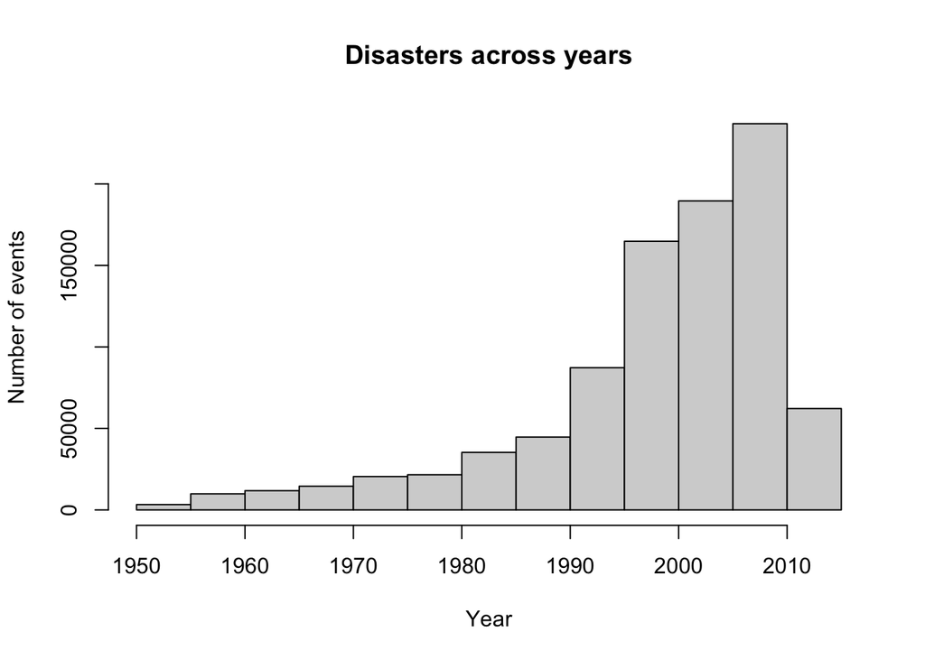

```r
hist(data1$year, main = "Disasters across years", xlab = "Year", ylab = "Number of events")
```

# Data Analysis (cont)

## Question: What type of event type cause the most harm to population health

To answer this question, we will look into the fatalities and injuries variable

Caculating the total fatalities of each types of event. Since there are a lots of events type, it would be helpful to only take the top 10 events that caused the most fatalities.

```r
totalfatal<-aggregate(data1$FATALITIES~data1$EVTYPE, data=data1, sum)
colnames(totalfatal)<- c("Events", "Fatalities")
totalfatalsorted<- totalfatal[with(totalfatal, order(-totalfatal$Fatalities)),][1:10,]
```

Calculating the total injuries of each event types.

```r
totalInjury<-aggregate(data1$INJURIES~data1$EVTYPE, data=data1, sum)
colnames(totalInjury)<-c("Events", "Injuries")
totalInjurysorted<- totalInjury[with(totalInjury, order(-totalInjury$Injuries)),][1:10,]
```

Now plotting the total fatalities and total injuries side by side to see which events caused the most harm to public health

```r
library(ggplot2)
library(ggpubr)
```

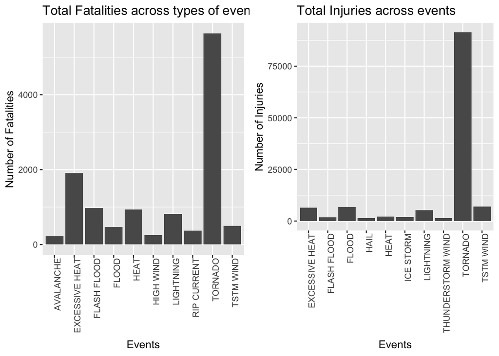

```r
FA<-ggplot(data=totalfatalsorted, aes(x= Events, y= Fatalities))+
  geom_bar(stat='identity')+
  xlab("Events")+ylab("Number of Fatalities")+
  ggtitle("Total Fatalities across types of event")+
  theme(axis.text.x = element_text(angle = 90, hjust = 1,margin = margin(b = 5)))

INJ<-ggplot(data=totalInjurysorted, aes(x=Events, y=Injuries))+
  geom_bar(stat='identity')+
  xlab("Events")+ylab("Number of Injuries")+
  ggtitle("Total Injuries across events")+
  theme(axis.text.x = element_text(angle = 90, hjust = 1, margin = margin(b = 5)))

ggarrange(FA,INJ, nrow=1)
```

## Across the US, which types of events caused the most economic damages?

To analyze the economic damages, we will investigate the 2 variables: property damage (propdmg) and crop damage (cropdmg)

First step, caculate the total property damage based on events type. Get the top 10 most costly disaster

```r
totalPROP<-aggregate(data1$PROPDMG~data1$EVTYPE, data=data1, sum)
colnames(totalPROP)<- c("Events", "PropDamage")
totalPROPsorted<- totalPROP[with(totalPROP, order(-totalPROP$PropDamage)),][1:10,]
```

Repeat the same steps with Crop damage

```r
totalCROP<-aggregate(data1$CROPDMG~data1$EVTYPE, data=data1, sum)
colnames(totalCROP)<- c("Events", "CropDamage")
totalCROPsorted<- totalCROP[with(totalCROP, order(-totalCROP$CropDamage)),][1:10,]
```

Plot the total crop damage and total property damage, and evaluate economic consequences

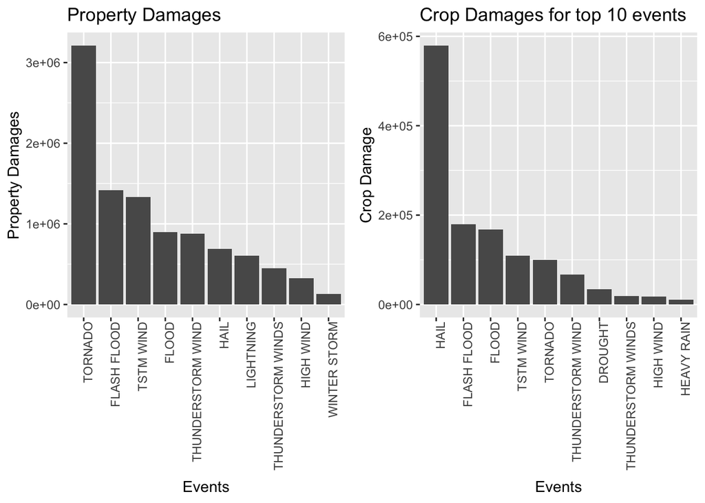

```r
PROP<-ggplot(data=totalPROPsorted, aes(x= reorder(Events,-PropDamage), y= PropDamage))+
  geom_bar(stat='identity')+
  xlab("Events")+ylab("Property Damages")+
  ggtitle("Property Damages")+
  theme(axis.text.x = element_text(angle = 90, hjust = 1,margin = margin(b = 5)))

CROP<-ggplot(data=totalCROPsorted, aes(x= reorder(Events, -CropDamage), y= CropDamage))+
  geom_bar(stat='identity')+
  xlab("Events")+ylab("Crop Damage")+
  ggtitle("Crop Damages for top 10 events")+
  theme(axis.text.x = element_text(angle = 90, hjust = 1,margin = margin(b = 5)))

ggarrange(PROP,CROP, nrow=1)
```

# Results/Conclusion

From graph 1, we see that tornado caused the most injuries and fatalities across the board. The second type of event that caused the most death is excessive heat. While with Injuries, TSTM Wind, Flood and Excessive Heat are on the same tier, 2nd place.

From the 2nd graph, most of the property damage is caused by tornado, while hail caused the most crop damages expense.